# Text Mining

Applying tidytext text mining methods to Boris Johnsons 10th May 2020 address

Ben Andersoncontact: b.anderson@soton.ac.uk `@dataknut`)

Last run at: 2020-05-12 09:48:10

# 1 About

## 1.1 Code

Source:

- https://github.com/dataknut/covid19

History:

- https://github.com/dataknut/covid19/commits/master

## 1.2 Comments and feedback

If you wish to comment please open an issue:

- https://github.com/dataknut/covid19/issues

## 1.3 Citation

If you wish to refer to any of the material from this report please cite as:

- Ben Anderson, (2020) Text Mining: Applying tidytext text mining methods to Boris Johnsons 10th May 2020 address , [Sustainable Energy Research Group](http://www.energy.soton.ac.uk), University of Southampton: Southampton, UK.

Report circulation:

- Public

This work is (c) 2020 the University of Southampton.

# 2 Introduction

An attempt to learn text mining using Boris Johnson’s televised address on May 10th 2020.

Data: https://www.gov.uk/government/speeches/pm-address-to-the-nation-on-coronavirus-10-may-2020

Methods draw very heavily on https://www.tidytextmining.com ([Text Mining with R: A Tidy Approach](http://shop.oreilly.com/product/0636920067153.do), Julia Silge and David Robinson, 2020-03-07)

# 3 The data

A [relatively short speech/address](https://www.gov.uk/government/speeches/pm-address-to-the-nation-on-coronavirus-10-may-2020) of 94 sentences outlining the framework for easing UK (actually English) lockdown.

```r
nWords <- nrow(tidy_df)
nWordsReduced <- nrow(reduced_df)

kableExtra::kable(head(df), caption = "First 6 sentences") %>% kable_styling()
```

Table 3.1: First 6 sentences

| line |
| --- |
| It is now almost two months since the people of this country began to put up with restrictions on their freedom – your freedom – of a kind that we have never seen before in peace or war. |
| And you have shown the good sense to support those rules overwhelmingly. |
| You have put up with all the hardships of that programme of social distancing. |
| Because you understand that as things stand, and as the experience of every other country has shown, it’s the only way to defeat the coronavirus - the most vicious threat this country has faced in my … |
| And though the death toll has been tragic, and the suffering immense. |
| And though we grieve for all those we have lost. |

# 4 Word frequency by postive/negative sentiment

We use the [`bing` sentiment data](https://www.cs.uic.edu/~liub/FBS/sentiment-analysis.html) to assign `sentiment` (positive vs negative) to each non-stopping word used and calculate the frequency.

Figure 4.1 shows the frequency of these words by sentiment.

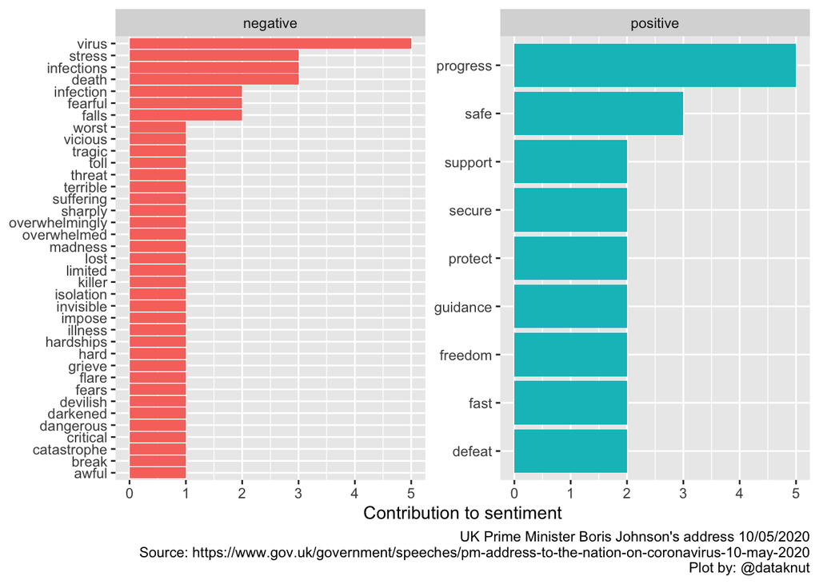

Figure 4.1: Frequency of words by sentiment

```r
bing_word_countsPlot
```

Figure 4.2 shows a word cloud of these words by sentiment.

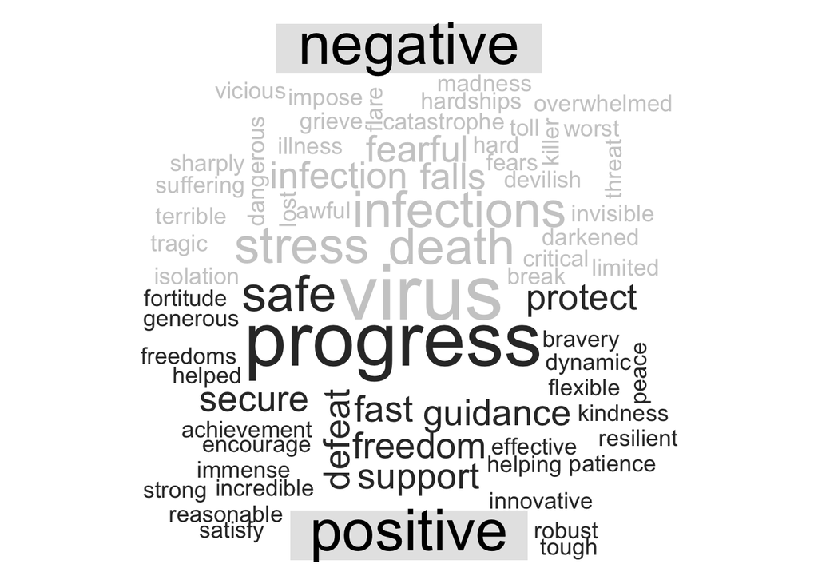

Figure 4.2: Wordcloud of words by sentiment

```r
# for some reson we can't capture this as a plot in the R script?
wc <- reduced_df %>% inner_join(get_sentiments("bing")) %>% count(word, sentiment, sort = TRUE) %>%
    reshape2::acast(word ~ sentiment, value.var = "n", fill = 0)

wordcloud::comparison.cloud(wc, colors = c("gray80", "gray20"), max.words = 100)
```

# 5 Frequency of sentiment by line

Figure 5.1 shows the number of positive/negative words by line (sentence) number. As we can see there are positive words at the very start followed by negative words, then a mix and then a positive finale.

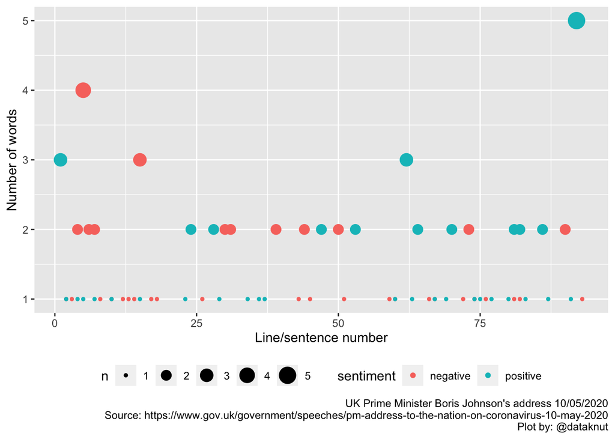

Figure 5.1: Frequency of entiment by line number

```r
sentimentByLinePLot
```

# 6 Runtime

Report generated using knitr in [RStudio](http://www.rstudio.com) with R version 3.6.3 (2020-02-29) running on x86_64-apple-darwin15.6.0 (Darwin Kernel Version 19.4.0: Wed Mar 4 22:28:40 PST 2020; root:xnu-6153.101.6~15/RELEASE_X86_64).

```r
t <- proc.time() - myParams$startTime

elapsed <- t[[3]]
```

Analysis completed in 4.579 seconds ( 0.08 minutes).

R packages used in this report:

- ggplot2 - (Wickham 2009)
- here - (Müller 2017)
- kableExtra - (Zhu 2018)
- readr = (Wickham, Hester, and Francois 2016)
- reshape2 - (Wickham 2007)
- tidytext - (Silge and Robinson 2016)
- tidyverse - (Wickham 2017)
- wordcloud - (Fellows 2018)

# References

Fellows, Ian. 2018. *Wordcloud: Word Clouds*. https://CRAN.R-project.org/package=wordcloud.

Müller, Kirill. 2017. *Here: A Simpler Way to Find Your Files*. https://CRAN.R-project.org/package=here.

Silge, Julia, and David Robinson. 2016. “Tidytext: Text Mining and Analysis Using Tidy Data Principles in R.” *JOSS* 1 (3). The Open Journal. https://doi.org/10.21105/joss.00037.

Wickham, Hadley. 2007. “Reshaping Data with the reshape Package.” *Journal of Statistical Software* 21 (12): 1–20. http://www.jstatsoft.org/v21/i12/.

———. 2009. *Ggplot2: Elegant Graphics for Data Analysis*. Springer-Verlag New York. http://ggplot2.org.

———. 2017. *Tidyverse: Easily Install and Load ’Tidyverse’ Packages*. https://CRAN.R-project.org/package=tidyverse.

Wickham, Hadley, Jim Hester, and Romain Francois. 2016. *Readr: Read Tabular Data*. https://CRAN.R-project.org/package=readr.

Zhu, Hao. 2018. *KableExtra: Construct Complex Table with ’Kable’ and Pipe Syntax*. https://CRAN.R-project.org/package=kableExtra.